# The intricacies of college data.

Project: Data Engineering

Author

Aymane Omari

Published

31 July 2023

Below is the necessary library needed to produce this report.html file.

**expand for full code**

```r
library(tidyverse)
```

# ⚙️ Setup

Here is how to obtain the CSV file “row_dataset.csv” that we can find on the ‘data/row’ subfolder:

```r
source("R/data_collection.R")
raw_folder_path <- file.path("data", "raw", "raw_dataset.csv")
num_universities <- 2000
get_top_universities_data(raw_folder_path, num_universities)
```

This process takes around 30 minutes.

To make this row data tidy (arrange the data, put relevant tiles, and only take the most relevant information) and get the same document we see in ‘data/tidy’, we need to use the following function from our preprocessing file:

```r
source("R/preprocessing.R")
input_file_path <- file.path("data", "raw", "raw_dataset.csv")
output_file_path <- file.path("data", "tidy", "tidy_dataset.csv")

process_enriched_data_to_tidy(input_file_path, output_file_path)
```

# 💾 The Data

In this project, I gathered data about the top 2000 universities worldwide through 3 steps:

- Web Scraping the top 2000 universities from CWUR rankings
- Obtaining more information from APIs in Wikipedia
- Scraping additional information from the Wikipedia Webpage, fetching additional data.

I then preprocessed the information and discarded columns that were irrelevant to the analysis (e.g html links, reference page numbers…).

-> One significant process I faced was handling inconsistencies in university names and formatting variations between different sources. I used string manipulation and replacement functions to ensure uniformity.

Here is a glimpse to the enriched dataset.

**expand for full code**

```r
# Read the tidy dataset
top_universities_dataset <- read.csv("data/tidy/tidy_dataset.csv")

# Display the structure of the dataset
glimpse(top_universities_dataset)
```

```
Rows: 2,000
Columns: 8
$ ranking            <int> 1, 2, 3, 4, 5, 6, 7, 8, 9, 10, 11, 12, 13, 14, 15, …
$ link_access        <chr> "Harvard_University", "Massachusetts_Institute_of_T…
$ location           <chr> "USA", "USA", "USA", "United Kingdom", "United King…
$ name               <chr> "Harvard University", "Massachusetts Institute of T…
$ description        <chr> "Harvard University is a private Ivy League researc…
$ typeUni            <chr> "Private research university", "Private land-grant …
$ founding_date      <chr> "1636", "1861", "1891", "1209", "1096", "1746", "18…
$ number_of_students <chr> "21,648 (Fall 2021)[6]", "11,858 (2022-2023)[5]", "…
```

I believe that the data’s significance lies in its comprehensive coverage and its enriched nature. Using various techniques, I incorporated different sources, bolstering dataset insight into each university’s attributes. As you can see, the final dataset consists of university rankings, names, locations, descriptions, university types, founding dates, and number of students. This data is easily manipulable for further analysis and rich in options to explore.

# 🚁 Big Picture

Here are four plots meant to provide a bigger picture of the dataset. Note that there is a function that takes the path as an argument for all these 4 plots.

**expand for full code**

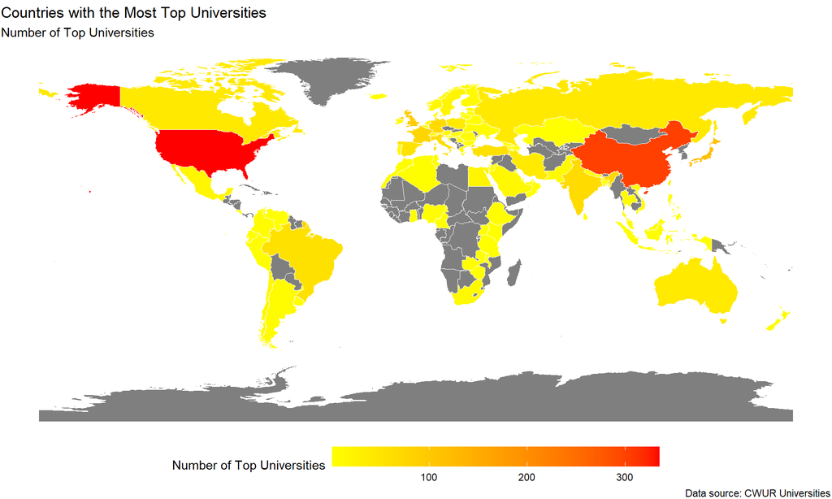

```r
source("R/data_viz.R")

# Call the function with the specified file path
create_universities_map("data/tidy/tidy_dataset.csv")
```

*Please note that the countries in gray contain no university in the CWUR top 2000 universities.*

The distribution of top universities is very unequal in the world. Reasons for this could be population variations or country development.

**2. Type of university using text mining**

Using text mining on the “typeUni” column, we produce a circular plot to observe the different types of universities and their distribution in the top 2000.

**expand for full code**

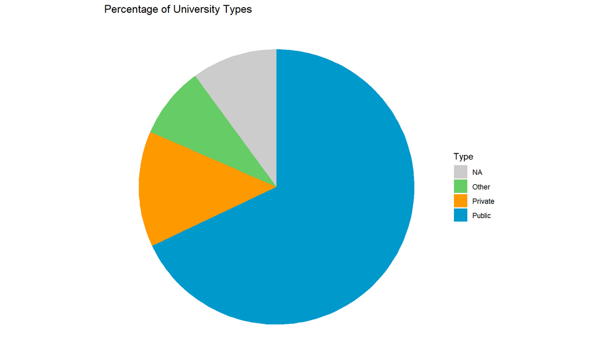

```r
source("R/data_viz.R")
plot_university_types("data/tidy/tidy_dataset.csv")
```

**3. Temporal Dimension of the Data**

It is also interesting to look at when these top universities were established.

**expand for full code**

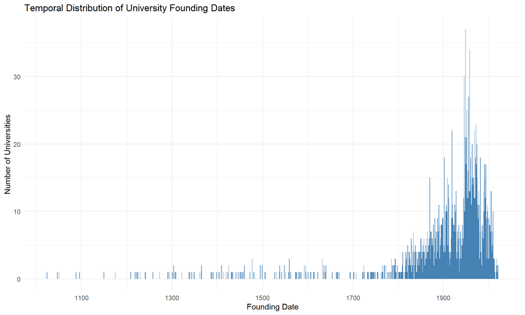

```r
source("R/data_viz.R")
plot_temporal_distribution("data/tidy/tidy_dataset.csv")
```

**4. Mean Ranking by Number of Students**

We are using the number of student here to see how many are in the university depending on the ranking.

**expand for full code**

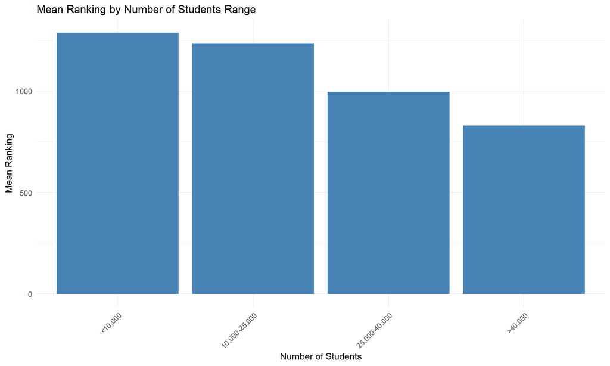

```r
source("R/data_viz.R")
plot_mean_ranking_by_students("data/tidy/tidy_dataset.csv")
```

Unsurprisingly, the more the number of students is high, the least the mean ranking will be. This can mean that a university with a higher ranking has more resources to provide to its students.

# 📈 Further Exploratory Analysis

Below are three plots meant to give a further understanding of the dataset and its intricacies. It is worth noting that for each of these 3 plots, a function has been made and takes the path of the document as an argument.

**1. Number of Students in Type of University**

It might be interesting to explore the number of students in each type of university.

**expand for full code**

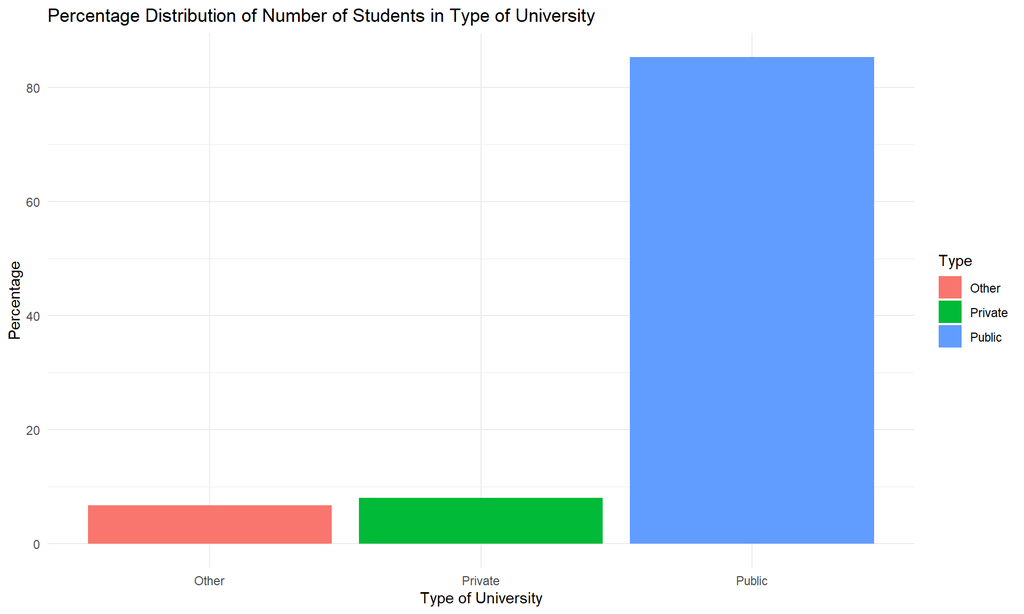

```r
source("R/data_viz.R")
plot_students_by_university_type("data/tidy/tidy_dataset.csv")
```

Public universities account for a larger share of students compared to private universities, which could indicate that public universities are more prevalent to students in the dataset. The reasons for this observation could vary and might be influenced by factors such as:

- Funding from the government, making the facilities of a higher quality
- Affordability of the university, enabling the student to attend
- Less selective admission policies

**2. Trends of University Types by Ranking Range**

In our purpose of exploring the trends in university types further, we are going to display the percentage of each university type across different ranking ranges.

**expand for full code**

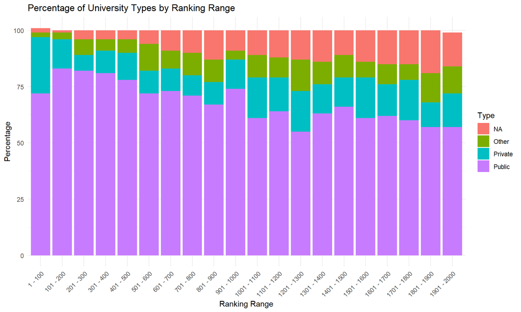

```r
source("R/data_viz.R")
plot_university_types_by_ranking("data/tidy/tidy_dataset.csv")
```

This plot reveals interesting trends:

The numerous private universities in the top 100 suggests that a number of private universities have achieved high rankings and are recognized for their academic excellence. With that said, we can see that as the ranking range expands beyond the top 100, there is a significant drop in their number. Many factors could explain this: - Public universities often have larger budget and funding, which puts them at an advantage in terms of research opportunities, infrastructure, and faculty resources - Public universities, especially those with state funding, might offer more affordable tuition rates, making them more accessible

**3. Type of university depending on location**

It would be interesting to see how the percentage of type of university varies across locations.

**expand for full code**

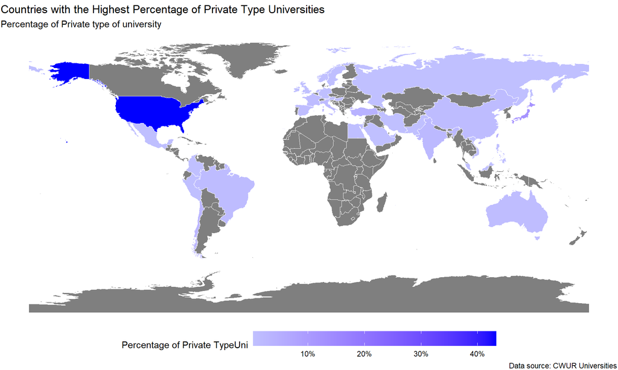

```r
source("R/data_viz.R")
plot_private_universities_map("data/tidy/tidy_dataset.csv")
```

*Note that countries in gray do not have any university described as private in the top 2000.*

We see that in most countries, except the USA, the vast majority of universities are public.

The USA stands out as an outlier in terms of having a substantial percentage of private universities compared to most other countries. This is likely due to the country’s unique higher education system, where private universities can sometimes provide more financial aid than public universities, and the offerings some private universities provide over public universities.

*Note that all plots are stored in ‘data/plots’*

**Conclusion of this research study and plots we explored**

In conclusion, the analysis of the top 2000 universities worldwide reveals significant insights into the global landscape of higher education:

The prevalence of public universities in most countries and the rise of private universities in certain ranking ranges prompt further exploration into funding, accessibility, and educational policies.

# ⏭️ Future

If I had more time to work in this project, I would:

- investigate in way more depth the data depending on each country. All nations have different policies when it comes to university. For instance, China mostly has public universities with some niche exceptions, as opposed to the US where there are a lot of private universities.
- collect more data. For instance, the acceptance rate for each university or its endowment would have been valuable to explore.
- use more rankings: indeed, I only used the CWUR ranking source which can lead to a biased ranking that only accounts for specific metrics.
- create dataframes by subject: the ranking used was global and did not delve into the fields of study for each university. If I had more time, it would also be an area I would explore.

*One practice that helped me throughout this process and that I plan on keeping in the future is brainstorm on a piece of paper to gather ideas on the plots I could make. This was very useful for me and I am happy it led to me producing these 7 plots!*